# Sensitivity of song diversification and evolution inference

## Quantify sensitivity

We might want to quantify sensitivity to the alignment strategy. We can see how much of the posterior distribution of a parameter under a “query” alignment falls outside the 95% HPD interval of a “target” alignment. A higher non-overlap means the alignments produce different results. If query A falls within target B, but a lot of query B falls outside target A, then the alignment B produces a broader (more uncertain) posterior than alignment A.

This could be helpful to see if there is a lek or parameter that is particularly sensitive to the alignment strategy.

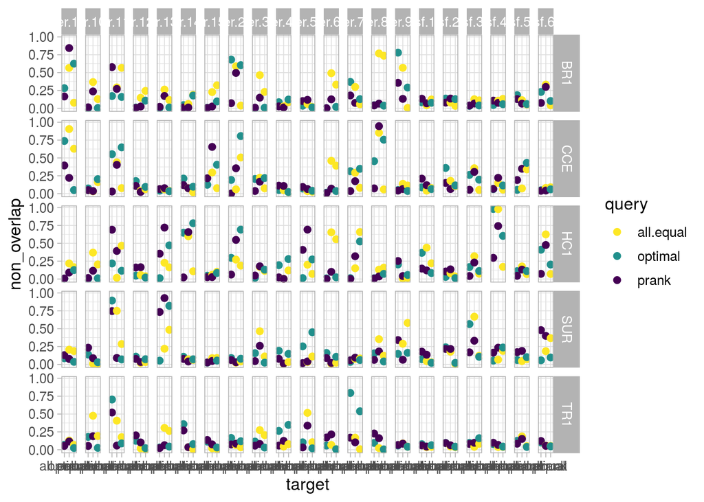

```r
evol_pars <- colnames(dat_com)[grep(pattern = "[f,r]\\.", colnames(dat_com))]

n <-  length(lek)*length(aln)*length(evol_pars)*2
overlap_df <-
  data.frame(
    lek = character(length = n),
    query = character(length = n),
    target = character(length = n),
    par = character(length = n),
    contrast = character(length = n),
    non_overlap = numeric(length = n)
  )

m <- 1
for (i in lek) {
  for (j in aln) {
    for (k in evol_pars) {
      tmp_data <-
        dat_com[which(dat_com$lek == i & dat_com$aln == j), k]
      for (h in aln) {
        if (j != h) {
      tmp_query <-
        dat_com[which(dat_com$lek == i & dat_com$aln == h), k]
      l <- HPDinterval(mcmc(tmp_data))[1]
      u <- HPDinterval(mcmc(tmp_data))[2]
      below_l <- length(which(tmp_query < l))
      above_u <- length(which(tmp_query > u))
      No_overlap <- below_l  + above_u
      overlap_df$lek[m] <- i
      overlap_df$query[m] <- h
       overlap_df$target[m] <- j
      overlap_df$par[m] <- k
      overlap_df$contrast[m] <- paste0(h, " vs ", j)
      overlap_df$non_overlap[m] <- No_overlap / length(tmp_data)
      m = m+1
        }
      }
    }
  }
}

overlap_wide <- pivot_wider(overlap_df, names_from = par, values_from = non_overlap)

p_evol_s_aln <-
  ggplot(data = overlap_df, aes(x = target, y = non_overlap, colour = query)) +
  geom_point(size = 2) +
  facet_grid(rows = vars(lek), cols = vars(par)) +
  theme_light(base_size = 12) +
  scale_colour_manual(values = aln_cols)

p_evol_s_aln
```